# final_report

Chaeeun Kim

04-24-2026

# Introduction

This analysis uses the CDC dataset titled “Tobacco Use 3 Months Before and Last 3 Months of Pregnancy.” The dataset provides population-level data on maternal smoking behavior before pregnancy and during the last trimester across participating states in the United States.

The objective of this analysis is to compare smoking prevalence before pregnancy and during the last trimester and to examine regional differences in tobacco use reduction. Because maternal smoking is a well-established risk factor for adverse birth outcomes, reductions in smoking during pregnancy represent an important public health objective.

All analyses were conducted using a fully reproducible workflow.

# Descriptive Analysis

## Tabular Analysis

The dataset was filtered to include smoking behavior before pregnancy and during the last trimester (QUO30 and QUO31). It was then reshaped to compare prevalence across time periods and to calculate the reduction in smoking for each location.

Smoking Prevalence Before vs Late Pregnancy (2011)

CDC PRAMStat

| Location | Before Pregnancy (%) | Last 3 Months (%) | Absolute Reduction (%) |
| --- | --- | --- | --- |
| New Mexico | 25.9 | 9.0 | 16.9 |
| Nebraska | 27.2 | 10.9 | 16.3 |
| West Virginia | 44.8 | 29.0 | 15.8 |
| Arkansas | 34.6 | 19.1 | 15.5 |
| Missouri | 33.6 | 18.5 | 15.1 |
| Colorado | 22.9 | 7.8 | 15.1 |
| Minnesota | 23.4 | 8.9 | 14.5 |
| Hawaii | 19.3 | 5.0 | 14.3 |
| Michigan | 29.2 | 14.9 | 14.3 |
| Pennsylvania | 27.0 | 12.9 | 14.1 |
| Maine | 33.3 | 19.2 | 14.1 |
| Wyoming | 29.6 | 15.7 | 13.9 |
| Rhode Island | 22.9 | 9.7 | 13.2 |
| Delaware | 26.7 | 13.6 | 13.1 |
| Maryland | 19.9 | 7.0 | 12.9 |
| Oklahoma | 30.6 | 18.0 | 12.6 |
| Wisconsin | 24.8 | 12.2 | 12.6 |
| PRAMS Total | 22.6 | 10.2 | 12.4 |
| Oregon | 23.2 | 10.8 | 12.4 |
| Massachusetts | 20.1 | 8.5 | 11.6 |
| Washington | 20.2 | 8.7 | 11.5 |
| Vermont | 30.8 | 19.4 | 11.4 |
| New Jersey | 17.0 | 5.7 | 11.3 |
| New York (excluding NYC) | 21.8 | 10.6 | 11.2 |
| Georgia | 15.9 | 6.2 | 9.7 |
| New York City | 10.6 | 1.9 | 8.7 |
| Utah | 11.4 | 4.0 | 7.4 |

Table 1 summarizes smoking prevalence before pregnancy and during the last trimester across participating locations in 2011. All locations show a reduction in smoking prevalence during pregnancy. The largest absolute reductions were observed in New Mexico and Nebraska, whereas smaller reductions were observed in Utah and New York City. These findings suggest meaningful variation in smoking reduction across regions.

## Graphical Analysis

Below is a bar graph comparing smoking prevalence before pregnancy and during the last trimester across locations in the United States.

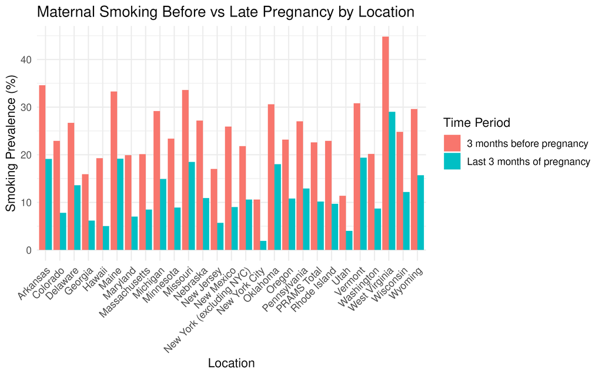

Figure 1 shows that smoking prevalence is consistently lower during pregnancy compared to before pregnancy across all locations. There is also notable geographic variation, with some locations exhibiting substantially higher prevalence levels than others.

# Interpretation

The results indicate that smoking prevalence consistently decreases during pregnancy across all locations, suggesting that pregnancy may motivate behavioral change. However, the magnitude of reduction varies considerably by location, indicating potential disparities in access to smoking cessation resources or public health interventions.

# Conclusion

This analysis demonstrates a consistent reduction in maternal smoking during pregnancy across locations in the United States. However, substantial geographic variation remains, indicating potential disparities in smoking cessation during pregnancy.

These findings highlight the importance of targeted public health interventions to reduce maternal smoking and improve birth outcomes.